# Life in BRC

## Experiences in Black Rock City, Community as Family, and Money Handling

## Experiences in Black Rock City

### Evaluation of Enjoyment of Experience* in Black Rock City

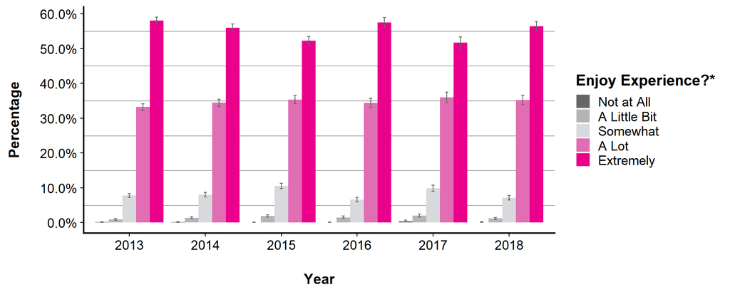

Error bars indicate the upper and lower bounds of the 95% confidence intervals.

* The exact wording of this question in the online survey was, "How much did you enjoy your experience this year in Black Rock City?"

|  | 2013 Percent | 2013 MoE +/- % |  | 2014 Percent | 2014 MoE +/- % |  | 2015 Percent | 2015 MoE +/- % |  | 2016 Percent | 2016 MoE +/- % |  | 2017 Percent | 2017 MoE +/- % |  | 2018 Percent | 2018 MoE +/- % |
| --- | --- | --- | --- | --- | --- | --- | --- | --- | --- | --- | --- | --- | --- | --- | --- | --- | --- |
| Not at All | 0.2 | 0.0 |  | 0.2 | 0.0 |  | 0.1 | 0.0 |  | 0.1 | 0.0 |  | 0.4 | 0.2 |  | 0.1 | 0.0 |
| A Little Bit | 0.9 | 0.2 |  | 1.4 | 0.2 |  | 1.9 | 0.4 |  | 1.5 | 0.4 |  | 2.0 | 0.4 |  | 1.2 | 0.2 |
| Somewhat | 7.8 | 0.6 |  | 8.0 | 0.6 |  | 10.5 | 0.8 |  | 6.6 | 0.8 |  | 9.9 | 0.8 |  | 7.1 | 0.6 |
| A Lot | 33.2 | 1.0 |  | 34.4 | 1.0 |  | 35.3 | 1.2 |  | 34.3 | 1.4 |  | 36.0 | 1.6 |  | 35.2 | 1.2 |
| Extremely | 58.0 | 1.0 |  | 56.0 | 1.2 |  | 52.2 | 1.2 |  | 57.5 | 1.4 |  | 51.7 | 1.6 |  | 56.4 | 1.4 |

## Experiences in Black Rock City

### Evaluation of Feelings of Safety* in Black Rock City

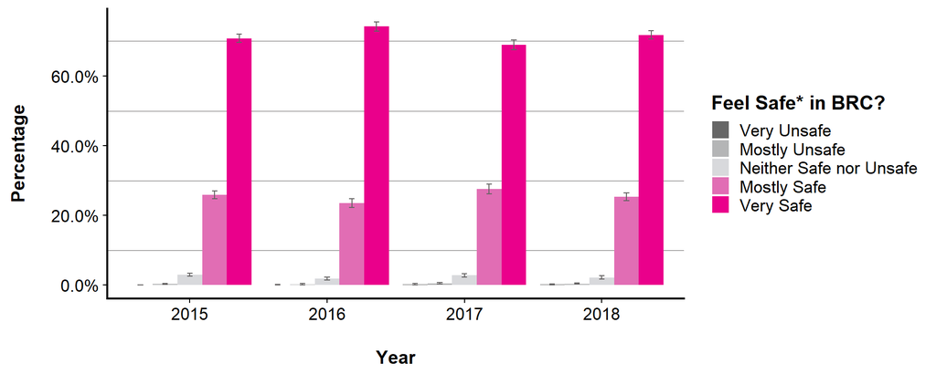

Error bars indicate the upper and lower bounds of the 95% confidence intervals.

* The exact wording of this question in the online survey was, "Did you feel safe in Black Rock City this year?"

|  | 2015 Percent | 2015 MoE +/- % |  | 2016 Percent | 2016 MoE +/- % |  | 2017 Percent | 2017 MoE +/- % |  | 2018 Percent | 2018 MoE +/- % |
| --- | --- | --- | --- | --- | --- | --- | --- | --- | --- | --- | --- |
| Very Unsafe | 0.0 | 0.0 |  | 0.1 | 0.0 |  | 0.2 | 0.2 |  | 0.2 | 0.2 |
| Mostly Unsafe | 0.3 | 0.2 |  | 0.2 | 0.2 |  | 0.5 | 0.2 |  | 0.4 | 0.2 |
| Neither Safe nor Unsafe | 3.0 | 0.4 |  | 1.9 | 0.4 |  | 2.8 | 0.6 |  | 2.2 | 0.4 |
| Mostly Safe | 25.9 | 1.2 |  | 23.5 | 1.2 |  | 27.6 | 1.4 |  | 25.3 | 1.2 |
| Very Safe | 70.8 | 1.2 |  | 74.2 | 1.2 |  | 68.9 | 1.4 |  | 71.8 | 1.2 |

## Experiences in Black Rock City

### Evaluation of Feelings of Connectedness* in Black Rock City

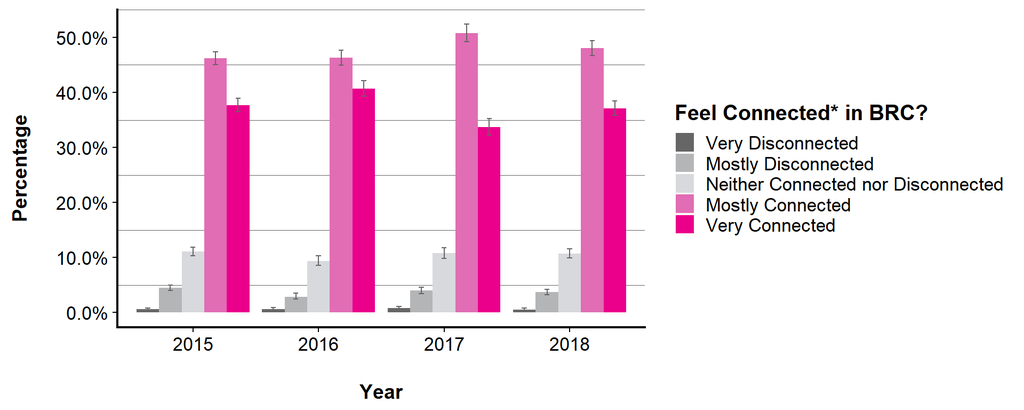

Error bars indicate the upper and lower bounds of the 95% confidence intervals.

* The exact wording of the question in the online survey was, "Did you feel connected to others around you in Black Rock City this year?"

|  | 2015 Percent | 2015 MoE +/- % |  | 2016 Percent | 2016 MoE +/- % |  | 2017 Percent | 2017 MoE +/- % |  | 2018 Percent | 2018 MoE +/- % |
| --- | --- | --- | --- | --- | --- | --- | --- | --- | --- | --- | --- |
| Very Disconnected | 0.6 | 0.2 |  | 0.6 | 0.2 |  | 0.8 | 0.2 |  | 0.5 | 0.2 |
| Mostly Disconnected | 4.5 | 0.6 |  | 2.9 | 0.4 |  | 4.0 | 0.6 |  | 3.7 | 0.6 |
| Neither Connected nor Disconnected | 11.1 | 0.8 |  | 9.4 | 0.8 |  | 10.8 | 1.0 |  | 10.7 | 0.8 |
| Mostly Connected | 46.2 | 1.2 |  | 46.3 | 1.4 |  | 50.8 | 1.6 |  | 48.0 | 1.4 |
| Very Connected | 37.7 | 1.2 |  | 40.7 | 1.4 |  | 33.7 | 1.6 |  | 37.1 | 1.4 |

## Evaluation of Burning Man Community as Family*

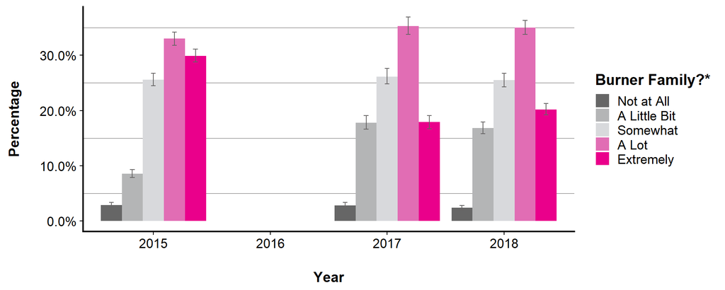

Error bars indicate the upper and lower bounds of the 95% confidence intervals.

* The exact wording of the question in the online survey was, "Do you consider the Burner community a family?" This question was not included in the 2016 online survey.

|  | 2015 Percent | 2015 MoE +/- % |  | 2016 Percent | 2016 MoE +/- % |  | 2017 Percent | 2017 MoE +/- % |  | 2018 Percent | 2018 MoE +/- % |
| --- | --- | --- | --- | --- | --- | --- | --- | --- | --- | --- | --- |
| Not at All | 2.9 | 0.4 |  | NA | NA |  | 2.8 | 0.6 |  | 2.4 | 0.4 |
| A Little Bit | 8.6 | 0.8 |  | NA | NA |  | 17.8 | 1.2 |  | 16.8 | 1.0 |
| Somewhat | 25.6 | 1.2 |  | NA | NA |  | 26.1 | 1.4 |  | 25.5 | 1.2 |
| A Lot | 33.0 | 1.2 |  | NA | NA |  | 35.3 | 1.6 |  | 35.0 | 1.2 |
| Extremely | 29.9 | 1.2 |  | NA | NA |  | 17.9 | 1.2 |  | 20.2 | 1.0 |

## Money Handling While in Black Rock City

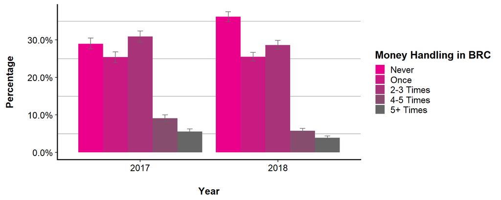

Error bars indicate the upper and lower bounds of the 95% confidence intervals.

|  | 2017 Percent | 2017 MoE +/- % |  | 2018 Percent | 2018 MoE +/- % |
| --- | --- | --- | --- | --- | --- |
| Never | 29.0 | 1.6 |  | 36.2 | 1.4 |
| Once | 25.4 | 1.4 |  | 25.5 | 1.2 |
| 2-3 Times | 30.9 | 1.4 |  | 28.6 | 1.2 |
| 4-5 Times | 9.1 | 1.0 |  | 5.8 | 0.6 |
| 5+ Times | 5.6 | 0.6 |  | 3.9 | 0.4 |

**Next:** Life in BRC: Camp Location, Camp Size, Family, Minors, and RV/Camper Use